# Búsquedas programáticas en la base de datos ENA

Última actualización:

15 de mayo de 2026

# PRÁCTICA 5

## Objetivos

1. Aprender a usar la API[^1] de [ENA](https://www.ebi.ac.uk/ena).

## Introducción

La base de datos ENA almacena diferentes tipos de secuencias nucleotídicas, y mucha información sobre cada uno de los *registros*. Desde la línea de comandos o desde un lenguaje de programación cualquiera podemos descargar tanto **metadatos**, mediante la API del *portal* de ENA; como **registros** (es decir, secuencias y la información que las acompaña), mediante la API del *navegador* (*browser*) de ENA.

La API del *portal* de ENA es una sintaxis para la confección de direcciones URL, con las cuales consultamos metadatos de los registros en la base de datos.

En el enlace siguiente encontrarás documentación sobre cómo realizar búsquedas avanzadas en ENA programáticamente usando esta API:

https://ena-docs.readthedocs.io/en/latest/retrieval/programmatic-access/advanced-search.html

Puedes también descargar un manual completo y actualizado de la ENA Portal API en el enlace siguiente: https://www.ebi.ac.uk/ena/portal/api/doc.

Tienes un ejemplo en la URL siguiente. Cópiala, pégala en la barra del navegador y accederás a una tabla que describe los registros de tipo *read run* (lecturas cortas) procedentes del estómago de vacas del Reino Unido:

```
https://www.ebi.ac.uk/ena/portal/api/search?result=read_run&query=country="United Kingdom" AND host_tax_id=9913 AND host_body_site="rumen"
```

Para extraer directamente las secuencias y su información asociada, ENA nos ofrece otro portal, con una API muy parecida: el ENA Browser Portal, cuya documentación deberíamos poder descargar de aquí: https://www.ebi.ac.uk/ena/browser/api/doc.

Como ejemplo, el enlace siguiente te permite descargar la secuencia del cromosoma mitocondrial de un neandertal.

`https://www.ebi.ac.uk/ena/browser/api/fasta/KJ533544`

Como ves, para poder descargar una secuencia (o más) necesitas conocer su número de acceso; KJ533544 en el ejemplo.

## La API del portal de ENA

Cualquier consulta dirigida al portal de ENA tomará la forma de una URL con la estructura siguiente:

1. La dirección del portal: `https://www.ebi.ac.uk/ena/portal/api`.
2. El **endpoint** `/search`, que especifica que realizamos una consulta o búsqueda. Existen otros *endpoints*.
3. Los parámetros de la búsqueda, que incluyen cinco campos separados por “&”:
- `/result=<tipo de datos>`, donde `<tipo de datos>` puede ser cualquiera de los *results* disponibles: *read_run*, *read_experiment*, *sample*, *study*, *sequence_release*, *sequence_update*, *wgs_set*, *tsa_set*, *assembly*, *coding_release*, *coding_update*, *noncoding_release*, *noncoding_update*, y *taxonomy*.
- Opcionalmente, `query=<filtros>`, donde `<filtros>` debe sustituirse por una o más condiciones que deben cumplir los registros para ser presentados. Las diferentes condiciones o filtros irán separadas por “AND”, “OR” o “NOT”. Existen reglas sobre cómo especificar cada posible filtro para cada posible tipo de resultado. Estas reglas están especificadas en la documentación del portal: https://www.ebi.ac.uk/ena/portal/api/doc.
- Opcionalmente, `fields=<campos>`, donde `<campos>` se debe sustituir por la lista, separada por comas, de los campos de información que deseamos extraer de cada registro. Es decir, las columnas que deseamos ver en la tabla de resultados. Cada tipo de `result` admite un conjunto de campos disponibles, que también están detallados en la documentación del portal.
- Opcionalmente, `limit=<límite>` donde `<límite>` representa el número máximo de registros (líneas) que queremos extraer en la tabla de resultados. Por defecto, el límite es 100000. Para no limitar la búsqueda, hay que especificar `limit=0`.
- Opcionalmente, `format=<formato>`, donde `<formato>` representa uno de dos valores posibles: `tsv` (*tab separated values*, usado por defecto) o `json`.

### Ejemplos

```
https://www.ebi.ac.uk/ena/portal/api/search?result=sequence&query=(specimen_voucher="ZMB:Moll:*" OR bio_material="ZMB:Moll:*")&fields=specimen_voucher,bio_material,scientific_name
```

```
https://www.ebi.ac.uk/ena/portal/api/search?result=analysis&query=country="United Kingdom" AND host_tax_id=9913 AND host_body_site="rumen" AND analysis_type="SEQUENCE_ASSEMBLY" AND assembly_type="primary metagenome"&fields=submitted_ftp
```

```
https://www.ebi.ac.uk/ena/portal/api/search?result=assembly&query=tax_tree(6157) AND genome_representation="full"&fields=version,tax_id,scientific_name,last_updated,base_count&limit=0
```

## Desde una sesión de R

La función `read.table()` puede leer directamente de una página web. Pero si queremos descargar el resultado de una consulta programática en un archivo, podemos usar el paquete la función `curl_download()`, del paquete `curl`.

```r
library('curl')
```

### Ejercicio 1

*Intenta ejecutar los bloques siguientes. Compáralos y explica qué problemas o dificultades identificas en cada uno.*

En este caso, al ejecutar el comando aparece el siguiente error: “URL using bad/illegal format or missing URL:

URL rejected: Malformed input to a URL function.

| Este bloque de código no funciona. Lo pongo enmarcado de esta manera para poder renderizar la práctica, sino no me dejaba. |
| --- |
| curl_download(‘https://www.ebi.ac.uk/ena/portal/api/search?result=assembly&query=tax_tree(6157) AND genome_representation=“full”&fields=version,tax_id,scientific_name,last_updated,base_count&limit=0’,… |

Este comando sí que se ha podido ejecutar correctamente. No ha aparecido ningún error. Ha descargado un primer archivo: una # tabla con varias columnas.

```r
curl_download(
  URLencode('https://www.ebi.ac.uk/ena/portal/api/search?result=assembly&query=tax_tree(6157) AND genome_representation="full"&fields=version,tax_id,scientific_name,last_updated,base_count&limit=0'),
  destfile = 'z1.txt')
```

En este comando tampoco me aparece que existe ningún error. Descarga una tabla exactamente idéntica a la anterior.

```r
portal <- 'https://www.ebi.ac.uk/ena/portal/api/search?'
result <- 'result=assembly&'
query <- 'query=tax_tree(6157)%20AND%20genome_representation=%22full%22&'
fields <- 'fields=version,tax_id,scientific_name,last_updated,base_count&'
limit  <- 'limit=0'
URL <- paste0(portal, result, query, fields, limit)
download.file(URLencode(URL), destfile = 'z2.txt', method = 'libcurl')
```

**Comparación:** El único de estos bloques en los que ha aparecido algún error ha sido en el primero. La diferencia es el URL encode. Podemos copiar el URL encode del primero en la consola de R y ejecutarlo. A la función URL encode le hemos dado una cadena de caracteres muy larga, nos devuelve una cadena en la que ha traducido algunos de los carácteres: ha cambiado lo justo para que la URL funcione cuando se la damos a la función curl download. Si a la cadena de carácteres original la copiamos y la traemos a una páginia del ordenador, funciona. Los navegadores también pueden traducir estos espacios y comillas. Vemos que son una lista de ensamblajes genómicos, que pertenecen al taxón 6157 y es una representación full (ensamblaje completo). Vemos el identificador, nombre del taxon, número de bases… Para averiguar a que taxon pertenece el 6157 –> https://www.ebi.ac.uk/ena/portal/api/search?result=taxon&query. Vemos que # pertenece al taxon de los platelmintos.

### Ejercicio 2

*Confecciona una URL para descargar una tabla de las secuencias codificantes de alcohol deshidrogenasas del género Drosophila, que te permita contestar las preguntas siguientes. Consulta el apéndice de este guión, si lo necesitas.*

La URL que he confeccionado se muestra a continuación. No sería necesaria incorporar la definición de portal y limit porque ya las hemos definido antes, pero yo las dejo aquí. El resultado si que lo tenemos que actualizar, ahora buscamos secuencias codificantes. Coding debe ir seguido de &. Lo podemos ir ejecutando línea por línea. Primero hemos probado en results con “coding” pero para este enzima no había ningún resultado. He vuelto a probar, pero con sequence.

```r
portal2 <- 'https://www.ebi.ac.uk/ena/portal/api/search?'
result2 <- 'result=sequence&'
query2  <- 'query=tax_tree(7215) AND description="alcohol dehydrogenase"&'
fields2 <- 'fields=tax_id,scientific_name,last_updated,base_count,first_public, description&'
limit2  <- 'limit=0'
URL2 <- paste0(portal2, result2, query2, fields2, limit2)
curl_download(URLencode(URL2 ), destfile = 'z3.txt')
```

1. *¿Cuántas secuencias hay con el término “alcohol dehydrogenase” en su descripción?*

```r
adh <- read.table('z3.txt', quote="", header=TRUE, sep="\t")
head(adh)
```

```
  accession tax_id       scientific_name last_updated base_count first_public
1  AF006567   7234 Drosophila persimilis   2005-04-15       3502   1997-09-11
2    U65746   7264   Drosophila buzzatii   2005-04-18       8725   1996-10-21
3    X00607   7240   Drosophila simulans   2005-04-18       4607   1985-06-13
4    M37276   7230 Drosophila mojavensis   2006-11-14       8783   1990-09-13
5  AY279325   7233      Drosophila orena   2006-11-14       1724   2004-03-31
6  KU559568   7244    Drosophila virilis   2016-06-24      14750   2016-05-31
                                                                                                                                                 description
1                                                 Drosophila persimilis alcohol dehydrogenase (Adh) and alcohol dehydrogenase (Adh-dup) genes, complete cds.
2 Drosophila buzzatii alcohol dehydrogenase (Adh-P) pseudogene, and alcohol dehydrogenase 2 (Adh-2) and alcohol dehydrogenase 1 (Adh-1) genes, complete cds.
3                                                                                                         Drosophila simulans gene for alcohol dehydrogenase
4                                             Drosophila mojavensis alcohol dehydrogenase-2 (Adh-2) and alcohol dehydrogenase-1 (Adh-1) genes, complete cds.
5                                Drosophila orena alcohol dehydrogenase (Adh) gene, partial cds and alcohol dehydrogenase related (Adhr) gene, complete cds.
6                                  Drosophila virilis strain 15010-1051.0 alcohol dehydrogenase (Adh1) and alcohol dehydrogenase (Adh2) genes, complete cds.
```

```r
dim(adh)
```

```
[1] 1258    7
```

2. *¿Qué longitudes tienen?*

   El siguiente código nos dirá el valor mínimo, primer cuartil, mediana, media, tercer cuartil y valor máximo:

```r
summary(adh$base_count)
```

```
   Min. 1st Qu.  Median    Mean 3rd Qu.    Max.
     44     590     839    1252     967   17499
```

3. *¿De cuántas especies diferentes son estas secuencias?*

   Le he puesto “length” delante para saber el número. Pero para ver las especies podría poner este código sin “lenght”.

```r
length(unique(adh$scientific_name))
```

```
[1] 308
```

4. *¿Cuándo se publicaron las más recientes?*

   Para conocer las más recientes, que serán las últimas de la tabla, usamos tail. Es decir, si usaramos head veríamos las más antiguas.

```r
tail(sort(adh$first_public))
```

```
[1] "2019-06-04" "2019-06-04" "2019-06-04" "2019-06-04" "2019-06-04"
[6] "2022-04-03"
```

## Trabajar con los resultados

La función `read.table()` de R nos permite leer un archivo (o una URL) para crear una tabla. Necesita que todas las filas tengan el mismo número de campos o columnas, delimitadas por el carácter especificado con la opción `sep = "\t"`. Esta función nos permite también especificar el tipo de datos de cada columna. Podemos usar como ejemplo los genomas de platelmintos del ejercicio 1:

```r
# Si no has ejecutado el tercer bloque del ejercicio 1,
# la variable URL no estará definida.
platelmintos <- read.table(URLencode(URL),
    header = TRUE,
    colClasses = c('numeric', 'factor', 'character', 'Date', 'numeric', 'character'),
    sep = '\t',
    na.strings = '')
```

El código siguiente crea una nueva columna en la tabla con el género al que pertenece cada secuencia. Se toma como género la primera palabra del nombre científico. Para ello, debemos separar las partes de cada nombre delimitadas por un espacio en blanco, con la función `strsplit()`. Y por último usamos la función `sapply()` para aplicar a cada nombre científico la función de selección de componentes, `[`, y la opción “1”, para seleccionar sólo el primero de los componentes en que habíamos dividido cada nombre científico.

```r
platelmintos$genus <- sapply(
   strsplit(platelmintos$scientific_name, ' '),
   '[',
   1)
```

Una vez clasificadas por género, podemos visualizar el número de bases de cada secuencia agrupadas por género.

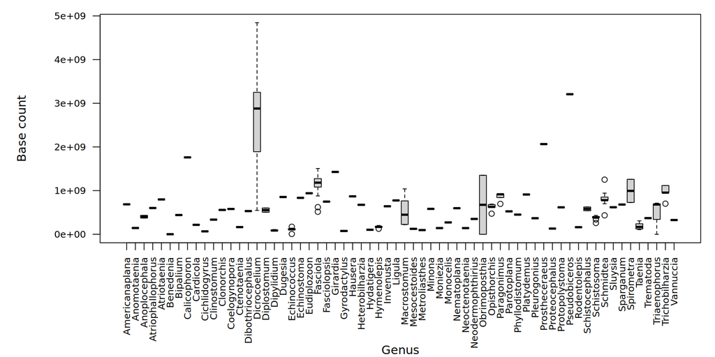

```r
par(mar = c(8,7,1,1))
boxplot(base_count ~ genus, data = platelmintos,
        las = 2, xlab = '', ylab = '', cex.axis = 0.8)
mtext('Genus', side = 1, line = 7)
mtext('Base count', side = 2, line = 5)
```

### Ejercicio 3

*¿De qué manera necesitarías transformar la tabla `platelmintos` para poder representar gráficamente la longitud acumulada de todas las secuencias disponibles a medida que se han ido publicando?*

```r
platelmintos2 <- platelmintos[order(platelmintos$last_updated), ]
platelmintos2$LongitudAcumulada <- cumsum(platelmintos2$base_count)
```

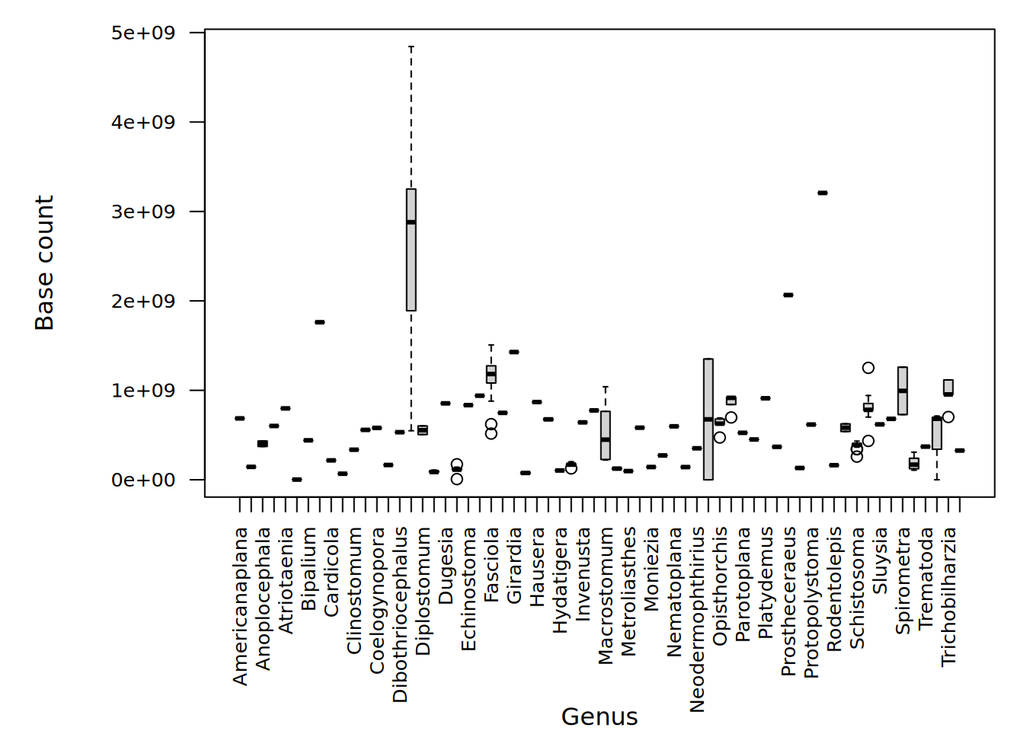

```r
par(mar = c(8,7,1,1))
boxplot(base_count ~ genus, data = platelmintos2,
        las = 2, xlab = '', ylab = '', cex.axis = 0.8)
mtext('Genus', side = 1, line = 7)
mtext('Base count', side = 2, line = 5)
```

## La API del navegador (*browser*) de ENA

Entre las secuencias obtenidas en el ejercicio 2, encontrarás las siguientes: AAC39011, AAY25307, ABU44510, ABG56046 y AAO06902. Vamos a descargarlas en formato fasta:

```r
portal    <- 'https://www.ebi.ac.uk/ena/browser/api/'
formato   <- 'fasta/'
accession <- 'AAC39011,AAY25307,ABU44510,ABG56046,AAO06902'
URL <- paste0(portal, formato, accession)
URL
```

```
[1] "https://www.ebi.ac.uk/ena/browser/api/fasta/AAC39011,AAY25307,ABU44510,ABG56046,AAO06902"
```

```r
curl_download(URL, destfile = 'Adh.fasta')
```

### Ejercicio 4

*Intenta descargar esas mismas secuencias en formato EMBL.*

Para ello:

```r
portal    <- 'https://www.ebi.ac.uk/ena/browser/api/'
formato2   <- 'embl/'
accession <- 'AAC39011,AAY25307,ABU44510,ABG56046,AAO06902'
URL2 <- paste0(portal, formato2, accession)
URL2
```

```
[1] "https://www.ebi.ac.uk/ena/browser/api/embl/AAC39011,AAY25307,ABU44510,ABG56046,AAO06902"
```

```r
curl_download(URL2, destfile = 'Adh.EMBL')
```

## Notas

[^1]: API: *Application programming interface*.